# Manual de uso del programa

El siguiente programa brinda un set de funciones para graficar las distribuciones de probabilidad. Aqui esta la lista de estas:

1. Distribución uniforme
2. Distribución triangular
3. Distribución normal
4. Distribución gamma
5. Distribución exponencial
6. Distribución beta
7. Distribución de Weibull
8. Distribución LogNormal
9. Distribución Erlanglar

### Instalación

#### 1) Descargar las siguientes dependencias

1. [ggplot2](https://ggplot2.tidyverse.org/)
2. [extraDistr](https://cran.r-project.org/web/packages/extraDistr/index.html)

#### 2) Importar funciones desde el archivo

```r
source("./distribution_functions.R")
```

### Parámetros de estilo

Todas las funciones cuenta con los siguientes dos parámetros: `fill`, `color`. `fill` determina el color interior de la distribución, mientras `color` determina el color del borde de la gráfica.

Estos están predeterminados a gris y negro si no se especifican. Estos son de tipo string y aceptan nombre de colores ya dados en R o en formato hexadecimal.

> Uso con colores predeterminados de R

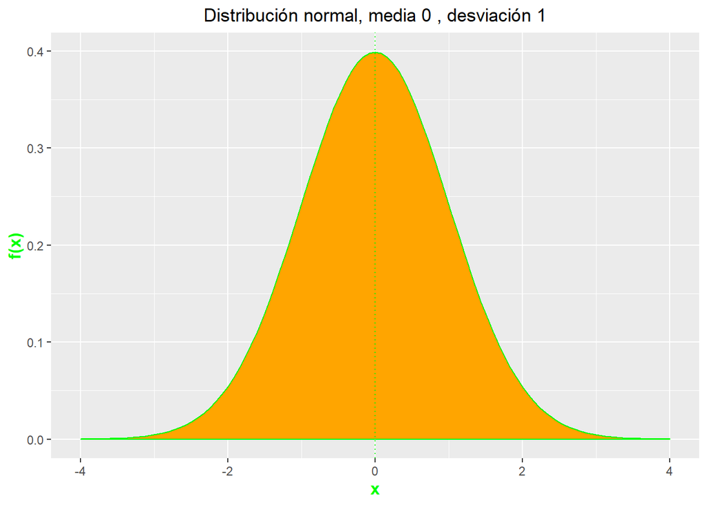

```r
plot_normal_distribution(fill = "orange", color = "green")
```

> Uso con hexadecimal

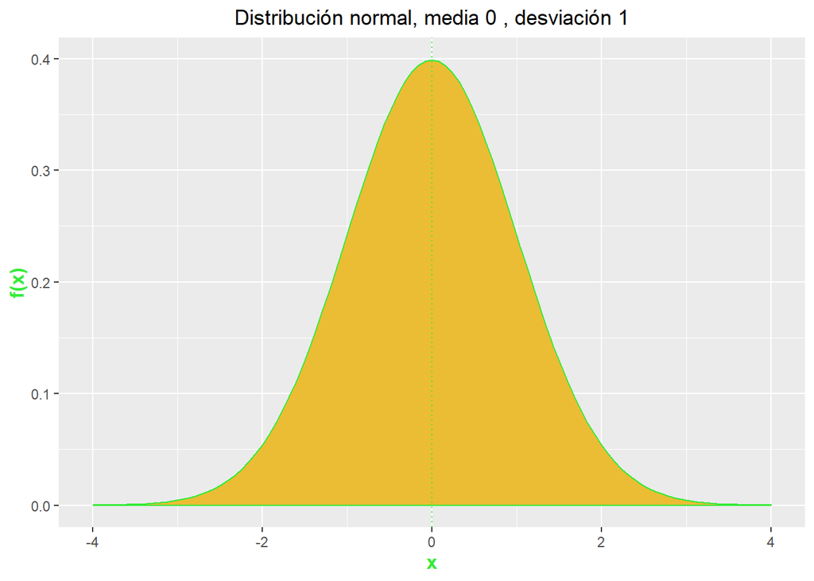

```r
plot_normal_distribution(fill = "#ebbd34", color = "#34eb37")
```

### Uso de las funciones

Todas las gráficas contienen una línea punteada que representa la media a fin de agregar información. Además, si se quiere saber el listado de funciones, solo ponga `plot_` y presione la tecla tab a fin de ver el listado.

> *Distribución normal*

Toma `mean` como media y `sd` como desviación estándar; estos están como 0 y 1, respectivamente.

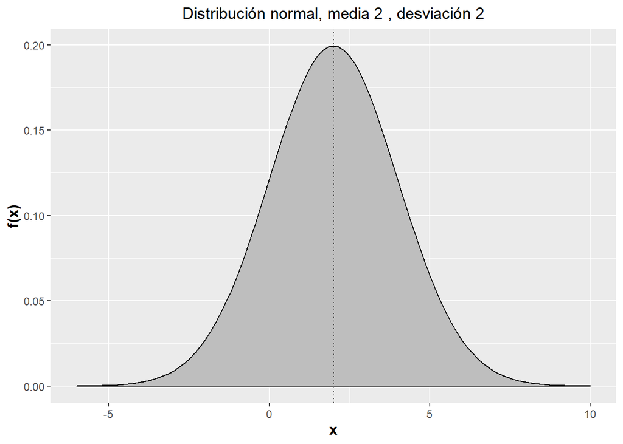

```r
plot_normal_distribution(mean = 2, sd = 2)
```

### Uso de las funciones

> *Distribución gamma*

Toma `alpha` como alpha y `beta` como beta; estos están como 2 y 2, respectivamente.

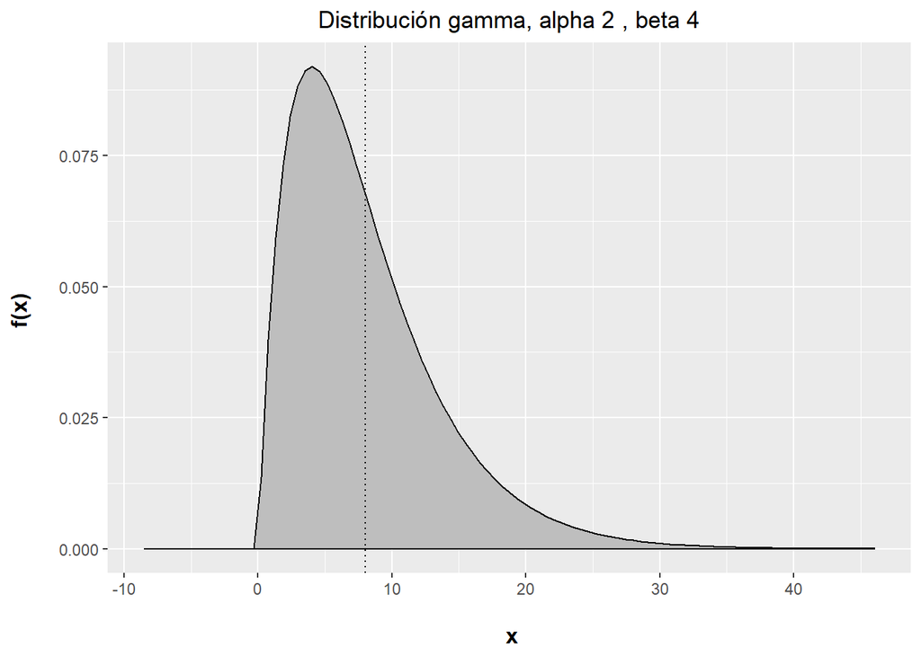

```r
plot_gamma_distribution(alpha = 2, beta = 4)
```